# How Does Energy Dependence Create Leverage?

Stephen Weymouth

Dean’s Professor

2026-10-26

# In the fall of 1973 U.S. gas stations ran out. Arab producers had used the oil weapon: they cut their output and stopped selling oil to the United States.

## Your IB Voice

Explain the change

In 1967 Arab producers cut their oil exports, and buyers bought oil elsewhere. In 1973 they cut supply again, and this time buyers could not replace it. What had changed?

**10 minutes** · Individual · Notes permitted

## Competing explanations

Why did the oil weapon work in 1973 when it had failed in 1967?

By 1973 U.S. wells were already pumping all they could, and U.S. imports had doubled since 1970.

Saudi Arabia supplied more of the world’s extra oil than any other country.

The producers cut how much oil they pumped, not just whom they sold to.

The public U.S. airlift and Nixon’s $2.2 billion aid request for Israel pushed Faisal to act.

The oil companies no longer set the price of oil.

Which of these would still have mattered if Texas had wells to spare, as in 1967?

# Why does oil matter so much?

## Oil became the world’s main source of energy

[figure not shown]

Energy Institute, [*Statistical Review of World Energy*](https://ourworldindata.org/grapher/oil-share-energy), 2025, and Smil (2017), via Our World in Data: share of primary energy from oil.

By 1973 oil supplied half of the world’s energy. It still supplies a third, more than coal or natural gas, and it runs almost all transport.

A jump in the price of oil reaches almost every business and household.

## Small supply cuts move the world price a lot

Oil is traded in one world market, so a buyer cut off from its supplier bids for oil meant for someone else.

In the short run buyers cannot use much less and producers cannot pump much more, so the price must jump.

[figure not shown]

Instructor’s illustration of U.S. Energy Information Administration, [*Oil prices and outlook*](https://www.eia.gov/energyexplained/oil-and-petroleum-products/prices-and-outlook.php), 2026.

*Price inelasticity* means that in the short run, buyers and producers change little when the price moves.

## Oil prices jump when supply is cut

[figure not shown]

U.S. Energy Information Administration, [*U.S. Crude Oil Composite Acquisition Cost by Refiners*](https://www.eia.gov/dnav/pet/hist/LeafHandler.ashx?n=PET&s=R0000____3&f=M), monthly, 2026, to August; [*WTI spot price*](https://www.eia.gov/dnav/pet/hist/LeafHandler.ashx?n=PET&s=RWTC&f=M) for September and October 2026.

Every large cut in supply raised the price within months, because buyers could not quickly use less.

A *supply shock* is a sudden loss of supply that buyers cannot quickly replace.

# Why did the oil weapon work in 1973?

# In 1972 King Faisal said it was “dangerous even to think of” using oil as a weapon. His kingdom depended on the United States for its security.

## By 1970 U.S. wells were pumping all they could

[figure not shown]

U.S. Energy Information Administration, [*Monthly Energy Review*](https://www.eia.gov/totalenergy/data/monthly/), 2026, Table 3.1: petroleum products supplied and net imports.

From 1959, import quotas limited cheaper foreign oil to protect U.S. producers, and in 1967 those wells pumped more when Arab exporters cut supply. By 1973 they could not keep up with demand, and Nixon ended the quotas.

*Energy dependence* is the share of a country’s oil use that it must buy from abroad.

## Saudi Arabia supplied the world’s extra oil

World oil use rose by almost a quarter between 1970 and 1973, while U.S. output fell.

Saudi Arabia supplied more than a third of the extra oil, and by 1973 even it was pumping at capacity.

[figure not shown]

Energy Institute, [*Statistical Review of World Energy*](https://ourworldindata.org/grapher/oil-production-by-country), 2025, via Our World in Data: oil production.

*Spare capacity* is oil production that can be brought online within 30 days and sustained for at least 90 days.

## Public U.S. aid to Israel triggered the embargo

[figure not shown]

Yergin, *The Prize* (2008), ch. 29.

In August Faisal had promised Egypt’s Anwar Sadat that he would use oil if war came.

The day after Nixon requested $2.2 billion for Israel, Saudi Arabia cut off the United States.

Yergin argues the public show of support gave Faisal his reason to act.

## The producers ranked their customers

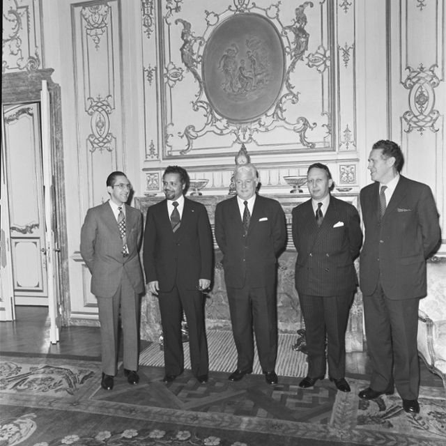

European Commission, [*Visit of Belaid Abdessalam and Ahmed Zaki Yamani to the CEC*](https://commons.wikimedia.org/wiki/File:Visit_of_Belaid_Abdessalam,_Algerian_Minister_for_Industry_and_Energy_and_Ahmed_Zaki_Yamani,_Saudi_Minister_for_Petroleum_and_Mineral_Resources,_to_the_CEC.jpg), 1973 · Wikimedia Commons, CC BY 4.0.

Arab ministers cut output each month but kept oil flowing to countries they judged friendly, such as Britain and France. Japan won an exemption by taking the Arab side.

A ban on one country leaks because oil can be resold, but a cut in supply reaches every buyer.

*Producer leverage* is a supplier’s power over buyers who cannot replace it.

# Who sets the price of oil?

## The exporters took the price from the companies

On October 16 the Gulf producers raised their price 70 percent without asking the companies.

With output cut, they raised the price again, and by 1974 it had nearly quadrupled.

[figure not shown]

Energy Institute, [*Statistical Review of World Energy*](https://www.energyinst.org/statistical-review), 2026: crude oil prices since 1861, via Our World in Data.

From 1973 to the mid-1980s producing governments, not the oil companies, set the price of oil.

## The companies’ side

In 1973 Aramco, owned by Exxon, Mobil, Texaco and Chevron, lobbied Washington for the Saudi position and then enforced the Saudi embargo against the United States. Why would U.S. companies take the Saudi side?

What can a firm do when its host state and its home state want opposite things?

# Does the oil weapon still work?

## The United States now sells more oil than it buys

[figure not shown]

U.S. Energy Information Administration, [*Monthly Energy Review*](https://www.eia.gov/totalenergy/data/monthly/), 2026, Table 3.1: net imports divided by products supplied.

Dependence on imports kept rising for three decades after the embargo and ended only when shale drilling raised U.S. output after 2010.

Ending dependence on imports did not end exposure to the world price of oil.

# On February 28, 2026, the United States and Israel struck Iran. Iran closed the Strait of Hormuz, which carried a fifth of the world’s oil.

## Importing countries released record oil stocks

[figure not shown]

Kilian, Plante, and Richter, [*What the Closure of the Strait of Hormuz Means for the Global Economy*](https://www.dallasfed.org/research/economics/2026/0320), Federal Reserve Bank of Dallas, 2026; International Energy Agency, [*IEA collective action*](https://www.iea.org/news/iea-confirms-member-country-contributions-to-collective-action-to-release-oil-stocks-in-response-to-middle-east-disruptions), 2026; CORES, *Release for consumption*.

Iran blocked the Gulf states that held most of the world’s spare oil. The importing countries of the International Energy Agency, founded after the 1973 embargo, released 400 million barrels from their emergency stocks.

*Emergency stocks* are oil that importing governments hold to replace supply lost in a crisis.

## Turn and talk

In 2026 Iran cut off about three times as much of the world’s oil as Arab producers did in 1973. Yet the price rose by about two-thirds, not fourfold. Why?

**5 minutes** · Pairs

## Iran’s leverage

In October Iran offered to reopen the strait if the United States lifted, among other things, its blockade of Iranian ports and its sanctions on Iranian oil. How does Iran’s leverage compare with Faisal’s in 1973?

Faisal could choose whom to cut off. Can Iran?

# Where is your industry exposed to energy?

## Find your industry’s energy exposure

1. **Select** one energy input your team’s network cannot run without, such as diesel, jet fuel, natural gas, or electricity.
2. **Diagnose** where it comes from, and what spare supply or stocks exist if one source is cut.
3. **Recommend** one way to reduce the exposure, such as a stockpile, a second supplier, or a different fuel.
4. **Decide** who would hold leverage over your industry in a supply shock.

**10 minutes** · Industry teams

## Report out

Which team’s industry is most exposed to an energy supply shock?

Who would hold leverage over that industry if the shock came?

## Takeaways

How does energy dependence create leverage?

Oil has one world price, so a cut in supply raises the price everywhere.

Buyers and producers adjust slowly, so small cuts cause large price jumps.

Producers gain leverage only when no one else has spare oil, as in 1973.

Producers could set the price only while buyers had nowhere else to go; when new oil came in the 1980s, the market took over again.

Buyers answered by building emergency stocks, which they drew on in 2026.